# Project 2: Data Mining, Classification, Prediction

SDS322E

12/10/2021

# Mining, Classification, Prediction

## Simran Shah sks3534

### Introduction

The first dataset I chose reports the percent of adults that reported experiencing symptoms related to depression and anxiety, and the percent of households that have lost or have not lost a income from employment (job), for each state in the U.S.A. The second dataset explored the availability of health care services, by reporting the number of visits made to federally qualified clinics, number of total federal clinics present, number of virtual clinics, number of service delivery sites, and lastly the total number of visits made to a physician, for each state and U.S territory. Both data sets have 52 USA states with 9 columns/variables to report for each state, after merging the two dataframes. There are no categorical variables present in the raw data. Categorical variables where created by assigning high and low levels to values above and below the median value for the number of clinical visits and percentage of households that have experienced job loss. In addition, the proportion of clinical visits was calculated by dividing the raw number of clinical visits for each state by the total number clinical visits. This data was collected relative to the start of the Covid-19 pandemic, and acquired via self-report surveys, physician reporting of clinical visits, and through the Health Resources and Services Administration data reporting. I picked these two dataset to see the relationship between mental health status (symptoms of depression and anxiety) and access to health care services, during the Covid-19 pandemic.

```r
library(tidyverse)

CHC_sites <- read.csv("~/project2/CHC_sites_csv.csv")
MD_covid <- read.csv("~/project2/MD_covid.csv")
merged_df <- left_join(MD_covid, CHC_sites, by = "Location") %>%
    mutate(Clinical.Visits = str_replace_all(Clinical.Visits,
        ",", ""), Clinical.Visits = as.numeric(Clinical.Visits),
        prop_clinicalVisits = Clinical.Visits/85678538, lowHigh_clinVisits = ifelse(Clinical.Visits >
            median(Clinical.Visits), "High", "Low"), lowHigh_lossIncome = ifelse(Household.Job.Loss.Since.March.2020 >
            median(Household.Job.Loss.Since.March.2020), "High",
            "Low"))
head(merged_df)
```

```
##        Location All.Adults Household.Job.Loss.Since.March.2020
## 1 United States      0.424                               0.534
## 2       Alabama      0.440                               0.624
## 3        Alaska      0.441                               0.541
## 4       Arizona      0.435                               0.567
## 5      Arkansas      0.430                               0.603
## 6    California      0.450                               0.544
##   No.Household.Job.Loss.Since.March.2020 Total.CHCs Service.Delivery.Sites
## 1                                  0.318      1,375                 13,555
## 2                                  0.299         17                    167
## 3                                  0.335         27                    201
## 4                                  0.329         23                    205
## 5                                  0.322         12                    168
## 6                                  0.331        175                  2,019
##   Clinical.Visits Virtual.Visits Total.Visits prop_clinicalVisits
## 1        85678538     28,530,608  114,209,146         1.000000000
## 2          816696        107,191      923,887         0.009532095
## 3          448175         96,936      545,111         0.005230890
## 4         2161084        973,631    3,134,715         0.025223166
## 5          901358         74,411      975,769         0.010520231
## 6        16709746      7,726,902   24,436,648         0.195028375
##   lowHigh_clinVisits lowHigh_lossIncome
## 1               High                Low
## 2                Low               High
## 3                Low               High
## 4               High               High
## 5                Low               High
## 6               High               High
```

### Cluster Analysis

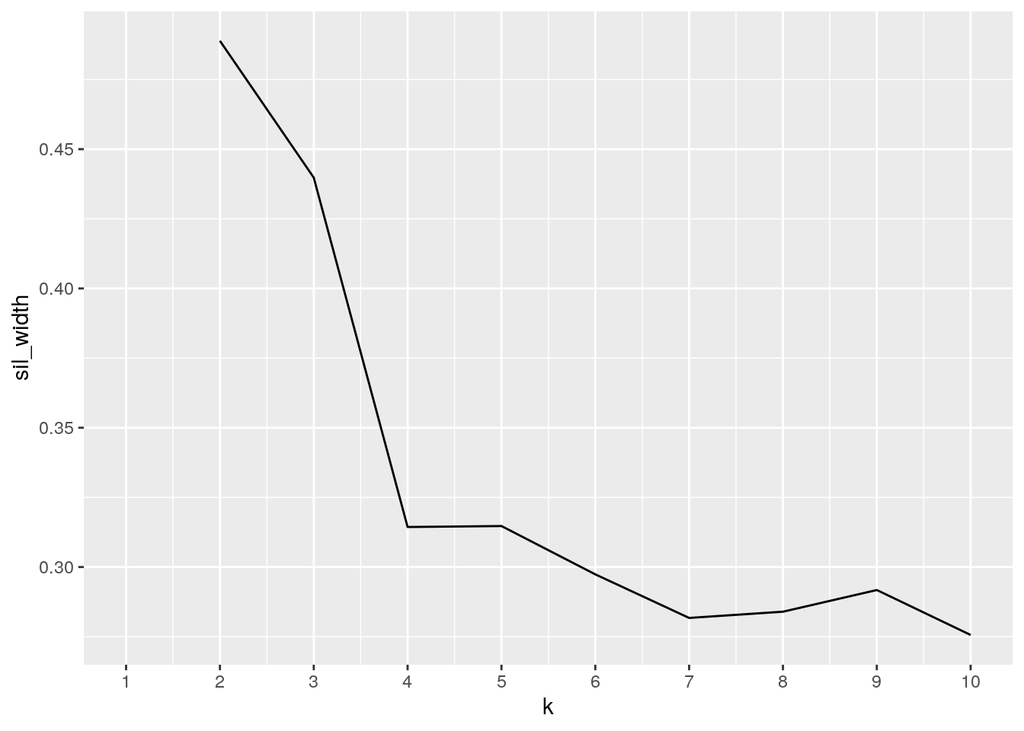

```r
# predict all adults based on household income loss, number
# of clinical visits, and service delivery sites
library(cluster)

dat2 <- merged_df %>% select(c("All.Adults", "lowHigh_clinVisits",
    "Household.Job.Loss.Since.March.2020", "Total.CHCs", "Virtual.Visits")) %>%
    mutate(lowHigh_clinVisits = as.factor(lowHigh_clinVisits)) %>%
    mutate(All.Adults = as.numeric(All.Adults)) %>% mutate(Household.Job.Loss.Since.March.2020 = as.numeric(Household.Job.Loss.Since.March.2020)) %>%
    mutate(Total.CHCs = as.numeric(Total.CHCs)) %>% mutate(Virtual.Visits = as.numeric(Virtual.Visits))

gower1 <- daisy(dat2, metric = "gower")

# Number of Clusters
sil_width <- vector()
for (i in 2:10) {
    pam_fit <- pam(gower1, diss = TRUE, k = i)
    sil_width[i] <- pam_fit$silinfo$avg.width
}
ggplot() + geom_line(aes(x = 1:10, y = sil_width)) + scale_x_continuous(name = "k",
    breaks = 1:10)
```

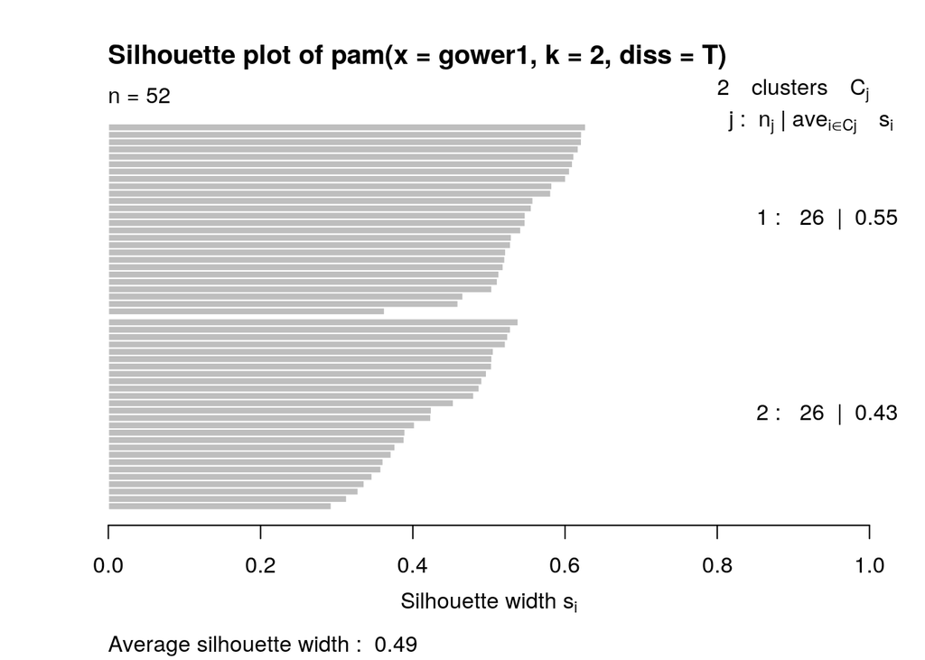

```r
# PAM clustering using gower
pam3 <- pam(gower1, k = 2, diss = T)
plot(pam3, which = 2)
```

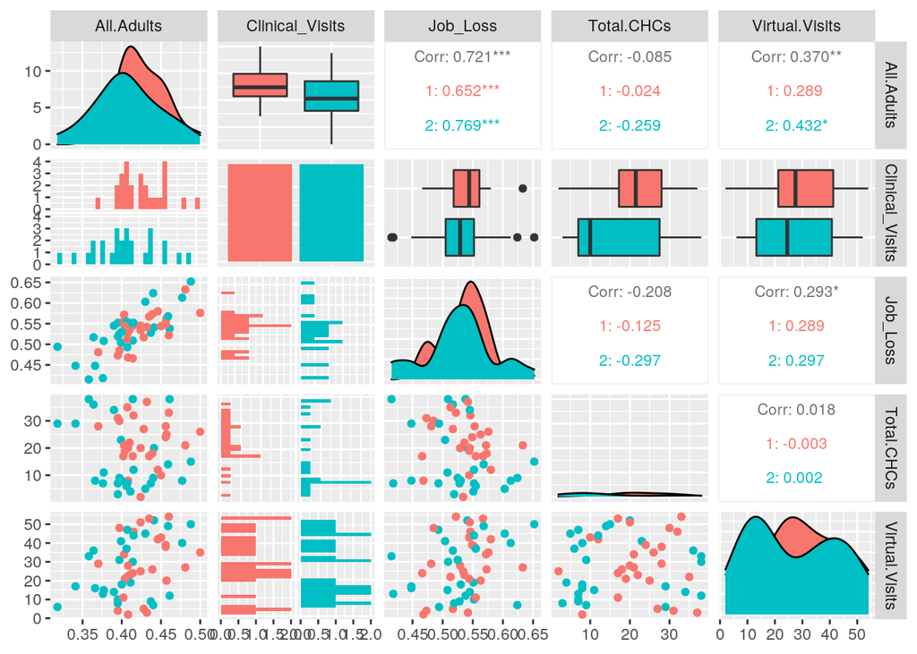

```r
colnames(dat2)[2] <- "Clinical_Visits"
colnames(dat2)[3] <- "Job_Loss"


# Visualization
library(GGally)
pair_plot <- ggpairs(dat2, columns = 1:5, aes(color = as.factor(pam3$clustering)),
    cardinality_threshold = 60, upper = list(continuous = wrap("cor",
        size = 3)))
pair_plot[4, 4] = pair_plot[4, 4] + scale_y_continuous(limits = 0:15)
pair_plot
```

From the merged dataframe, I subsetted out the following columns to perform clustering on: ‘All.Adults’, ‘lowHigh_clinVisits’, ‘Household.Job.Loss.Since.March.2020’, ‘Total.CHCs’, ‘Virtual.Visits’. With the subsetted dataframe, I performed gower clustering by including the categorical variable lowHigh_clinVisits, which categorizes the number of clinical visits into either low or high levels based on the median value. Based on the silhouette width plot, the goodness of fit line showed that 2 clusters has the highest average silhouette width. The average silhouette width is 0.49, indicating that the structure identified is weak and could potentially be artificially created. After determining that 2 clusters would be best, PAM clustering was performed on the numeric gower dissimilatiries. The pairwise plot shows the distribution of responses and correlation values for each variable in relation to each other. Based on the correlation values, the households that experienced job loss is strongly positively correlated with the percent of adults that reported symptoms of depression and anxiety. The total number of virtual visits conducted (for each U.S. state) is moderately positively correlated with the percent of adults that reported symptoms of depression and anxiety. The scatter plot for the percent of adults that reported symptoms of depression and anxiety and the number of households that experiences loss of employment is trending in a positive direction, which may support the strong positive correlation value. In conclusion, the distribution visualizations and correlation values indicate a relationship between job loss and experiencing symptoms related to depression and anxiety, which may be worth further diving into.

### Dimensionality Reduction with PCA

```r
dat2_nums <- dat2 %>% select(-c(Clinical_Visits)) %>% mutate(All.Adults = as.numeric(All.Adults)) %>%
    mutate(Job_Loss = as.numeric(Job_Loss)) %>% mutate(Virtual.Visits = as.numeric(Virtual.Visits)) %>%
    mutate(Total.CHCs = as.numeric(Total.CHCs))
dat2_pca <- princomp(dat2_nums)
names(dat2_pca)
```

```
## [1] "sdev"     "loadings" "center"   "scale"    "n.obs"    "scores"   "call"
```

```r
summary(dat2_pca, loadings = T)
```

```
## Importance of components:
##                            Comp.1     Comp.2       Comp.3       Comp.4
## Standard deviation     15.4357694 10.7966217 5.242646e-02 2.120574e-02
## Proportion of Variance  0.6714788  0.3285122 7.745988e-06 1.267309e-06
## Cumulative Proportion   0.6714788  0.9999910 9.999987e-01 1.000000e+00
##
## Loadings:
##                Comp.1 Comp.2 Comp.3 Comp.4
## All.Adults                    0.548  0.836
## Job_Loss                      0.836 -0.548
## Total.CHCs            -1.000
## Virtual.Visits  1.000
```

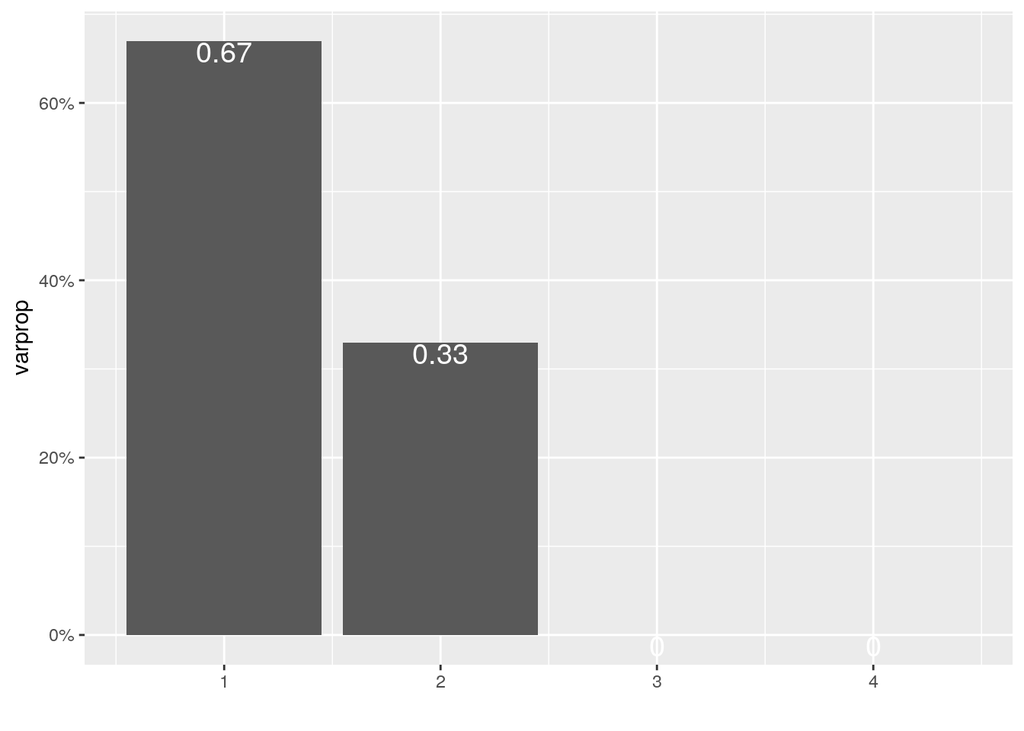

```r
eigval <- dat2_pca$sdev^2  #square to convert SDs to eigenvalues
varprop = round(eigval/sum(eigval), 2)  #proportion of var explained by each PC
ggplot() + geom_bar(aes(y = varprop, x = 1:4), stat = "identity") +
    xlab("") + geom_text(aes(x = 1:4, y = varprop, label = round(varprop,
    2)), vjust = 1, col = "white", size = 5) + scale_y_continuous(breaks = seq(0,
    0.6, 0.2), labels = scales::percent) + scale_x_continuous(breaks = 1:10)
```

```r
# PC1 and PC2
round(cumsum(eigval)/sum(eigval), 2)
```

```
## Comp.1 Comp.2 Comp.3 Comp.4
##   0.67   1.00   1.00   1.00
```

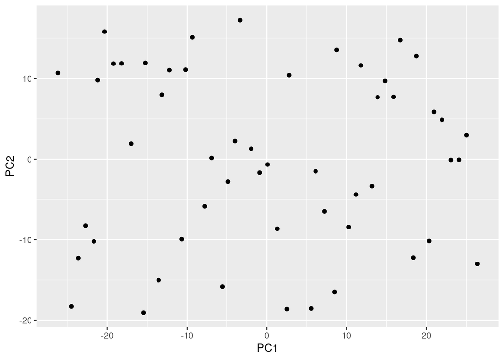

```r
# no variation/clustering of points
dat2_df <- data.frame(Name = merged_df$Location, PC1 = dat2_pca$scores[,
    1], PC2 = dat2_pca$scores[, 2])
ggplot(dat2_df, aes(PC1, PC2)) + geom_point()
```

### Linear Classifier

```r
dat3 <- merged_df %>% mutate(lowHigh_Adult_report = ifelse(All.Adults >
    median(All.Adults), "High", "Low")) %>% select(-c("lowHigh_clinVisits",
    "lowHigh_lossIncome", "All.Adults", "Location"))

fit <- glm(lowHigh_Adult_report == "High" ~ Household.Job.Loss.Since.March.2020 +
    Total.CHCs + Service.Delivery.Sites + Clinical.Visits + Virtual.Visits +
    Total.Visits + prop_clinicalVisits, data = dat3, family = "binomial")
score <- predict(fit, type = "response")
score %>% round(3)
```

```
##  1  2  3  4  5  6  7  8  9 10 11 12 13 14 15 16 17 18 19 20 21 22 23 24 25 26
##  1  1  1  1  1  1  1  0  0  1  1  1  0  1  0  0  0  1  1  1  0  0  1  1  0  1
## 27 28 29 30 31 32 33 34 35 36 37 38 39 40 41 42 43 44 45 46 47 48 49 50 51 52
##  0  0  0  1  0  1  1  0  0  0  1  1  1  0  0  0  0  0  1  0  0  0  1  1  0  0
```

```r
class_diag(score, truth = dat3$lowHigh_Adult_report, positive = "High")
```

```
##         acc sens spec ppv f1 ba auc
## Metrics   1    1    1   1  1  1   1
```

```r
set.seed(1234)
k = 10  #choose number of folds
data <- dat3[sample(nrow(dat3)), ]  #randomly order rows
folds <- cut(seq(1:nrow(dat3)), breaks = k, labels = F)  #create folds
diags <- NULL
for (i in 1:k) {
    ## Create training and test sets
    train <- data[folds != i, ]
    test <- data[folds == i, ]
    truth <- test$lowHigh_Adult_report  ## Truth labels for fold i
    ## Train model on training set (all but fold i)
    fit <- glm(lowHigh_Adult_report == "High" ~ as.numeric(Household.Job.Loss.Since.March.2020) +
        as.numeric(Total.CHCs) + as.numeric(Service.Delivery.Sites) +
        as.numeric(Clinical.Visits) + as.numeric(Virtual.Visits) +
        as.numeric(Total.Visits) + as.numeric(prop_clinicalVisits),
        data = train, family = "binomial")
    ## Test model on test set (fold i)
    probs <- predict(fit, newdata = test, type = "response")
    ## Get diagnostics for fold i
    diags <- rbind(diags, class_diag(probs, truth, positive = "High"))
}

summarize_all(diags, mean)
```

```
##    acc    sens spec   ppv      f1      ba     auc
## 1 0.82 0.83334  0.8 0.875 0.82405 0.81666 0.81666
```

```r
# confusion matrix No need for ifelse really, just make a
# table showing the TP, FP, TN, and FN counts. Just get your
# predicted probabilities from the model, use a threshold of
# .5 to classify a case as positive, and compare those with
# your actual/true values.

probs_all <- predict(fit, newdata = dat3, type = "response")
actual_predicted_df <- data.frame(Actual = dat3$lowHigh_Adult_report,
    Predicted = probs_all)
actual_predicted_df <- actual_predicted_df %>% mutate(Pred_highLow = ifelse(as.numeric(Predicted) >
    0.5, "High", "Low"))

y_hat <- factor(actual_predicted_df$Pred_highLow, levels = c("High",
    "Low"))
y <- factor(actual_predicted_df$Actual, levels = c("High", "Low"))
table(actual = y, predicted = y_hat)
```

```
##       predicted
## actual High Low
##   High   24   2
##   Low     3  23
```

Firstly, the percentage of adults who reported symptoms of depression and anxiety was converted into a categorical variable, with levels of ‘High’ and ’Low" assigned based on the median value. The area under the curve (AUC) and the accuracy metric (acc) when trying to predict the categorical variable - high and low levels of adults reporting symptoms- using the remaining numeric variables was 1, indicating that the generalized linear model (GLM) accurately classified all samples (US states) as either having a high or a low percentage of adults who reported symptoms of depression and anxiety. Then the model was trained on 46 sample and tested on a 6 samples, and a 10-cross validation was performed. Based on the trained model, the model is predicting new observations per cross validation at an overall (mean) AUC of 0.8166. We can see sign of overfitting because the model did not perform as well when cross-validating, indicated by the drop in AUC.

### Non-Parametric Classifier

```r
library(caret)

fit <- knnreg(as.factor(lowHigh_Adult_report) ~ ., data = dat3)
yhat <- predict(fit, newdata = dat3)
class_diag(yhat, dat3$lowHigh_Adult_report, positive = "High")
```

```
##         acc sens spec ppv     f1  ba    auc
## Metrics 0.5    1    0 0.5 0.6667 0.5 0.2618
```

```r
set.seed(1234)
k = 10  #choose number of folds
data <- dat3 %>% sample_frac()  #randomly order rows
folds <- cut(seq(1:nrow(dat3)), breaks = k, labels = F)  #create folds
diags <- NULL
for (i in 1:k) {
    train <- data[folds != i, ]
    test <- data[folds == i, ]
    ## Fit linear regression model to training set
    fit <- knnreg(as.factor(lowHigh_Adult_report) ~ ., data = train)
    ## Get predictions/y-hats on test set (fold i)
    train_probs <- predict(fit, newdata = test)
}
class_diag(train_probs, test$lowHigh_Adult_report, positive = "High")
```

```
##            acc sens spec    ppv  f1  ba    auc
## Metrics 0.3333    1    0 0.3333 0.5 0.5 0.3125
```

### Regression/Numeric Prediction

```r
fit <- lm(Total.Visits ~ as.numeric(Household.Job.Loss.Since.March.2020) +
    as.numeric(Service.Delivery.Sites), data = dat3)  #predict mpg from all other variables
yhat <- predict(fit)  #predicted mpg
mean((as.numeric(dat3$Total.Visits) - yhat)^2)  #mean squared error (MSE)
```

```
## [1] 229.6993
```

```r
set.seed(1234)
k = 5  #choose number of folds
data <- dat3[sample(nrow(dat3)), ]  #randomly order rows
folds <- cut(seq(1:nrow(dat3)), breaks = k, labels = F)  #create folds
diags <- NULL
for (i in 1:k) {
    train <- data[folds != i, ]
    test <- data[folds == i, ]
    ## Fit linear regression model to training set
    fit <- lm(Total.Visits ~ as.numeric(Household.Job.Loss.Since.March.2020) +
        as.numeric(Service.Delivery.Sites), data = train)
    ## Get predictions/y-hats on test set (fold i)
    yhat <- predict(fit, newdata = test)
    ## Compute prediction error (MSE) for fold i
    diags <- mean((as.numeric(test$Total.Visits) - yhat)^2)
}
mean(diags)  ## get average MSE across all folds (much higher error)!
```

```
## [1] 258.7634
```

```r
# MSE higher in CV, not good (means overfitting)!
```

A linear regression model was fit to the whole dataset, which resulted in a mean squared error (MSE) of 229.6993. When the linear model was fit to a train sample, consisting of 41 samples, and then ran on a test sample of 11 samples, the MSE was 258.7634. The MSE in the 5-fold cross validation (258.7634) is greater than when the linear model was fit the whole data set (229.6993), indicating slight overfitting.

### Python

```r
library(reticulate)
```

```python
import matplotlib.pyplot as plt
import pandas as pd
import numpy as np

states_list = list(r.merged_df.iloc[0:,0])

us_state_to_abbrev = {
    "Alabama": "AL",
    "Alaska": "AK",
    "Arizona": "AZ",
    "Arkansas": "AR",
    "California": "CA",
    "Colorado": "CO",
    "Connecticut": "CT",
    "Delaware": "DE",
    "Florida": "FL",
    "Georgia": "GA",
    "Hawaii": "HI",
    "Idaho": "ID",
    "Illinois": "IL",
    "Indiana": "IN",
    "Iowa": "IA",
    "Kansas": "KS",
    "Kentucky": "KY",
    "Louisiana": "LA",
    "Maine": "ME",
    "Maryland": "MD",
    "Massachusetts": "MA",
    "Michigan": "MI",
    "Minnesota": "MN",
    "Mississippi": "MS",
    "Missouri": "MO",
    "Montana": "MT",
    "Nebraska": "NE",
    "Nevada": "NV",
    "New Hampshire": "NH",
    "New Jersey": "NJ",
    "New Mexico": "NM",
    "New York": "NY",
    "North Carolina": "NC",
    "North Dakota": "ND",
    "Ohio": "OH",
    "Oklahoma": "OK",
    "Oregon": "OR",
    "Pennsylvania": "PA",
    "Rhode Island": "RI",
    "South Carolina": "SC",
    "South Dakota": "SD",
    "Tennessee": "TN",
    "Texas": "TX",
    "Utah": "UT",
    "Vermont": "VT",
    "Virginia": "VA",
    "Washington": "WA",
    "West Virginia": "WV",
    "Wisconsin": "WI",
    "Wyoming": "WY",
    "District of Columbia": "DC",
    "American Samoa": "AS",
    "Guam": "GU",
    "Northern Mariana Islands": "MP",
    "Puerto Rico": "PR",
    "United States Minor Outlying Islands": "UM",
    "U.S. Virgin Islands": "VI",
}

list_abb = list()
for keys, values in us_state_to_abbrev.items():
  if keys in states_list:
    print(values)
```

```
## AL
## AK
## AZ
## AR
## CA
## CO
## CT
## DE
## FL
## GA
## HI
## ID
## IL
## IN
## IA
## KS
## KY
## LA
## ME
## MD
## MA
## MI
## MN
## MS
## MO
## MT
## NE
## NV
## NH
## NJ
## NM
## NY
## NC
## ND
## OH
## OK
## OR
## PA
## RI
## SC
## SD
## TN
## TX
## UT
## VT
## VA
## WA
## WV
## WI
## WY
## DC
```

In the python code above, I subsetted out the ‘Locations’ column which contains the name of each state in the USA. Then I created a dictionary that matches the name of each state to its 2-letter abbreviation. Using a for loop with an if statement, I checked to see if the keys in the list matched the states in the location column, and printed out the correlating values (2-letter abbreviations).

### Concluding Remarks

Thank you! Have a wonderful break and holidays!